# Compare predictions

This script compares the predicted autumn senescense read from the ModelAnalysis_1_Predicted_DoYoff_subset.csv file provided by Zani et al. in Zenodo with the predictions resulting from evaluating the models using the optimal parameters read from ModelAnalysis_2_OptimalParameters_subset.csv and data.sub for 3 timeseries.

### A. Load subset of data for the demo

### B. Define the models

The models are defined as in Zani et al. 2020. For this demo, only the TPM, TPDM and PIA+ models are considered.

### C. Example 1. Timeseries: 1_Fagus_sylvatica

1. Select data for the timeseries
2. Plot observed versus predicted autumn senescence dates for the timeseries.
1. The predictions are read from the ModelAnalysis_1_Predicted_DoYoff_subset.csv file provided by Zani et al. in Zenodo. These predictions are calculated using the function estimate_phenology from the phenor package.

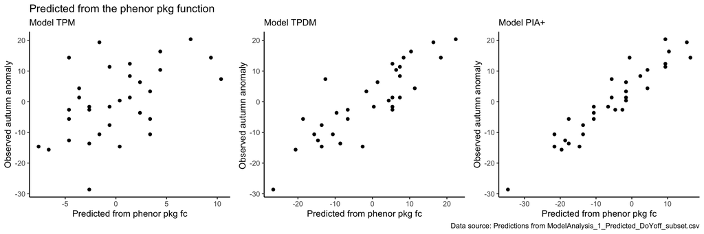

2. The predictions are calculated from the optimal parameters read from the ModelAnalysis_2_OptimalParameters_subset.csv file provided by Zani et al. in Zenodo. These predictions are the result of evaluating the models specified in the paper for the optimal parameters and the data.

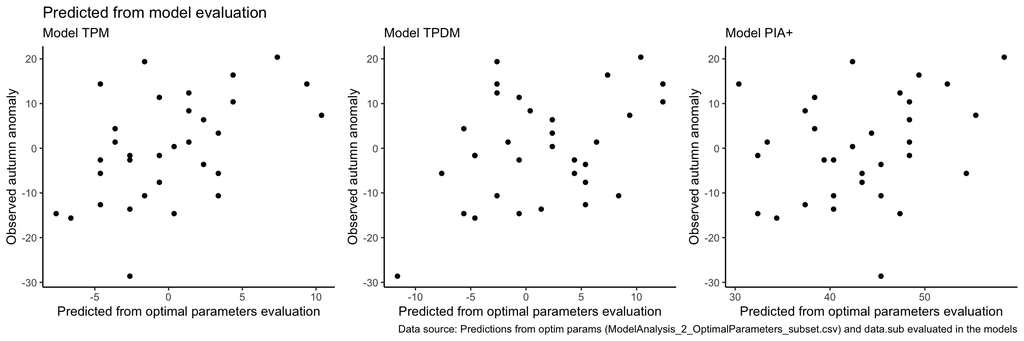

### Example 2. Timeseries: 1_Quercus_robur

1. Select data for the timeseries
2. Plot observed versus predicted autumn senescence dates for the timeseries.
1. The predictions are read from the ModelAnalysis_1_Predicted_DoYoff_subset.csv file provided by Zani et al. in Zenodo. These predictions are calculated using the function estimate_phenology from the phenor package.

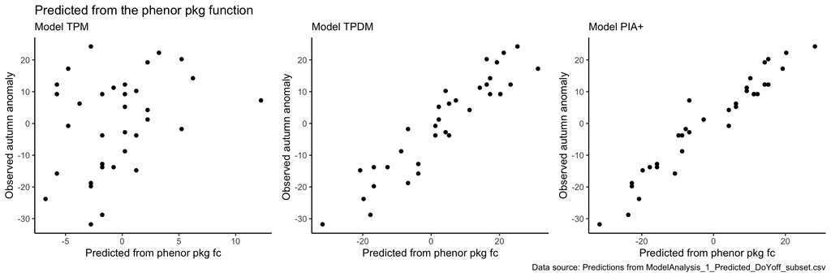

2. The predictions are calculated from the optimal parameters read from the ModelAnalysis_2_OptimalParameters_subset.csv file provided by Zani et al. in Zenodo. These predictions are the result of evaluating the models specified in the paper for the optimal parameters and the data.

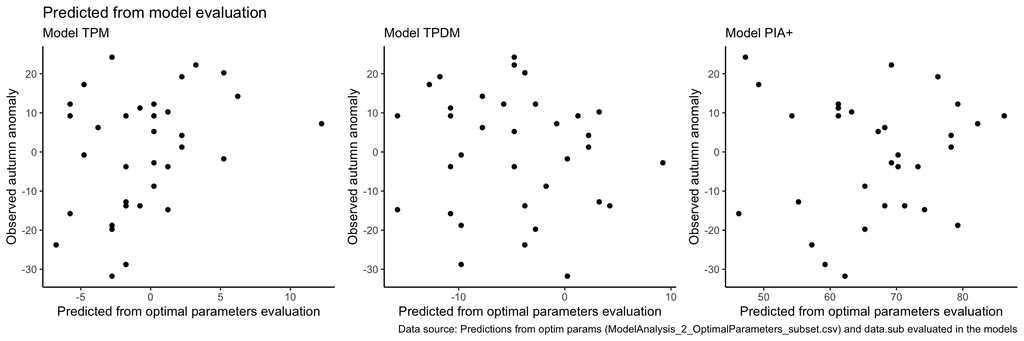

### Example 3. Timeseries: 1002_Aesculus_hippocastanum

1. Select data for the timeseries
2. Plot observed versus predicted autumn senescence dates for the timeseries.
1. The predictions are read from the ModelAnalysis_1_Predicted_DoYoff_subset.csv file provided by Zani et al. in Zenodo. These predictions are calculated using the function estimate_phenology from the phenor package.

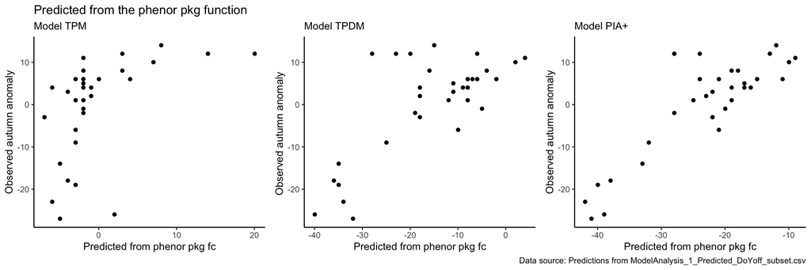

2. The predictions are calculated from the optimal parameters read from the ModelAnalysis_2_OptimalParameters_subset.csv file provided by Zani et al. in Zenodo. These predictions are the result of evaluating the models specified in the paper for the optimal parameters and the data.

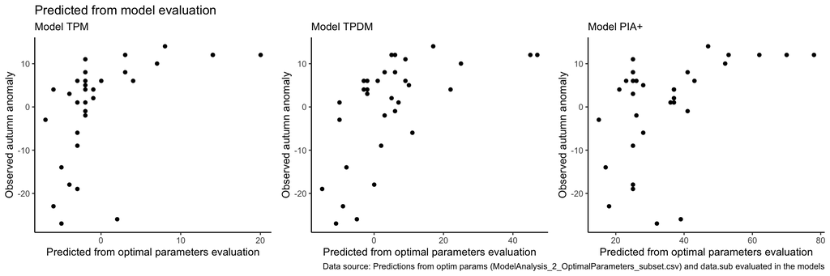